# Github - Atividade de usuários

Gileade Kelvin

28 de julho de 2017

```r
library(dplyr)
library(tidyr)
library(xts)
library(tibble)
library(highcharter)
library(ggplot2)
library(resample)
library(chron)
library(lubridate)
theme_set(theme_light())
```

## Sobre os dados

Os dados obtidos nessa análise consistem numa amostra de dados da atividade global do github. Os dados contém a contagem de quantas pessoas editaram arquivos com cada extensão de arquivo em cada dia de 2016 e 2017 no github. Para reforçar, estamos trabalhando com uma **amostra** dos dados.

```r
dados.github <- read.csv("github-users-committing-filetypes.csv")
```

```r
dados.github.summ <- dados.github %>%
  unite("date", the_year, the_month, month_day, sep = "-") %>%
  mutate(date = as.Date(strptime(date, "%Y-%m-%d"))) %>%
  group_by(date) %>%
  summarise(total = sum(users))
```

```r
dados.summ.stock <- dados.github.summ %>%
  remove_rownames %>%
  column_to_rownames(var="date")

dados.summ.stock.xts <- as.xts(dados.summ.stock)
```

```r
highchart(type = "stock") %>%
  hc_title(text = "Atividade Global no Github") %>%
  hc_subtitle(text = "Número de usuários que editaram arquivos no github") %>%
  hc_add_series(dados.summ.stock.xts, id = "git", name = "Git")
```

[interactive chart not shown]

Acima podemos observar a série temporal da atividade global do github durante o período disponível na amostra. É interessante notar um certo padrão na série, há altos e baixos com certa frequência e a linha parece uma onda ao longo do período. Há uma suspeita de que os **vales** sejam os fins de semana e os **picos** ou as **cristas** da “onda” sejam no meio de semana. Outra curiosidade interessante está nos considerados **feriados** que possuem escala mundial como Natal e Ano novo, é clara a diferença de atividade nessas datas com relação aos demais dias do ano.

## Pergunta 1

**Segunda e sexta têm popularidade menor que terça, quarta e quinta?**

Para responder a essa pergunta iremos considerar os cinco dias da semana e separá-los em dois grupos. Grupo 1 (Extremidades da semana) como segunda e sexta e o Grupo 2 (meio do meio da semana) como terça, quarta e quinta.

```r
library("lubridate")

dados.github.summ <- dados.github.summ %>%
  mutate(day_of_week = wday(date))

dados.github.extr <- dados.github.summ %>%
  filter(!day_of_week %in% c(1, 7)) %>%
  mutate(isEXT = day_of_week %in% c(2, 6))
```

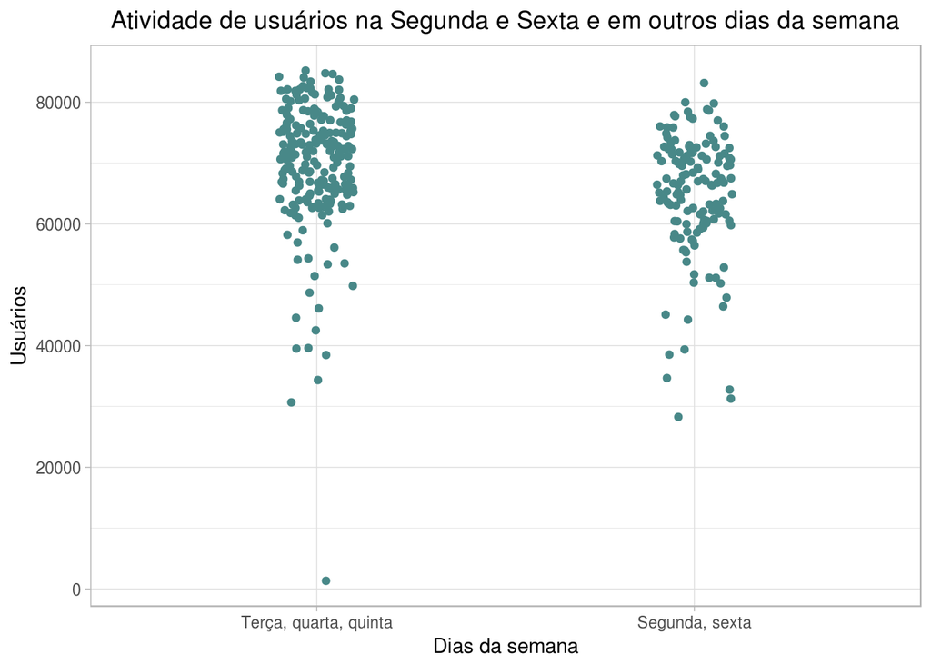

```r
set.seed(123)
dados.github.extr %>%
  ggplot(aes(x = isEXT, y = total)) +
  geom_jitter(width = .1, color = "#488888") +
  labs(title = "Atividade de usuários na Segunda e Sexta e em outros dias da semana", x = "Dias da semana", y = "Usuários") +
  scale_x_discrete(labels= c("Terça, quarta, quinta", "Segunda, sexta")) +
  theme(plot.title = element_text(hjust = 0.5))
```

Não parece haver uma diferença clara entre o grupo dos dias, mas precisamos investigar de forma mais objetiva antes de fazer alguma conclusão apenas no olho. Perceba que nossos olhos talvez não consigam perceber grandes diferenças por conta da escala. Para isso usaremos bootstrap e intervalo de confiança.

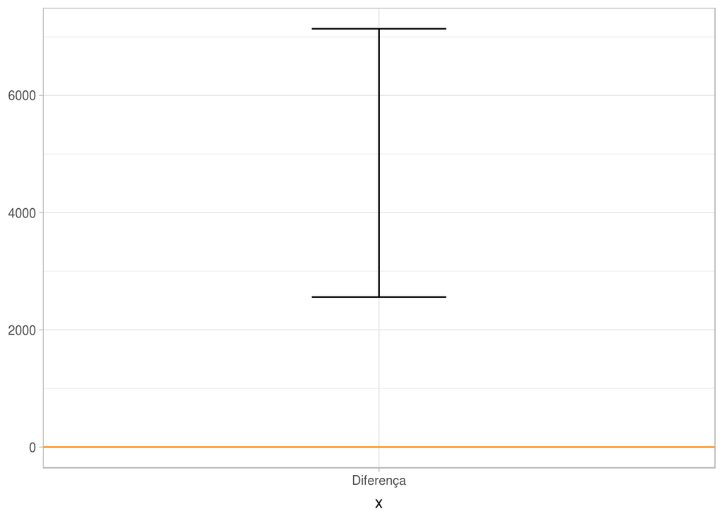

```r
median.dados.extr <- bootstrap2(dados.github.extr$total,
                          treatment = dados.github.extr$isEXT,
                          median,
                          R = 30000)

median.dados.extr.ci <- CI.percentile(median.dados.extr, probs = c(.025, .975))

data.frame(median.dados.extr.ci) %>%
  ggplot() +
  geom_errorbar(aes(x = "Diferença", ymin = X2.5., ymax = X97.5.), width = .2) +
  geom_hline(yintercept = 0, colour = "darkorange")
```

É possível dizer que com 95% de confiança a diferença das medianas, a partir das amostras (obtidas através do bootstrap), está no intervalo entre 2559, 7137. Ou seja, a diferença de atividade de usuários no Github entre *Terça, quarta, quinta* e *Segunda, sexta* é relevante e mostra que na parte do meio do meio de semana existe mais atividade do que nas extremidades (Segunda e sexta). Lembrando que estamos comparando os valores absolutos aqui e de forma não pareada considerando os dias do ano.

Mas qual será o dia entre segunda e sexta que possui menos atividade?

### Pergunta derivada

**Entre a segunda e sexta existe uma diferença significativa de popularidade?**

```r
dados.github.segsex <- dados.github.summ %>%
  filter(day_of_week %in% c(2, 6)) %>%
  mutate(isSEX = day_of_week %in% c(6))
```

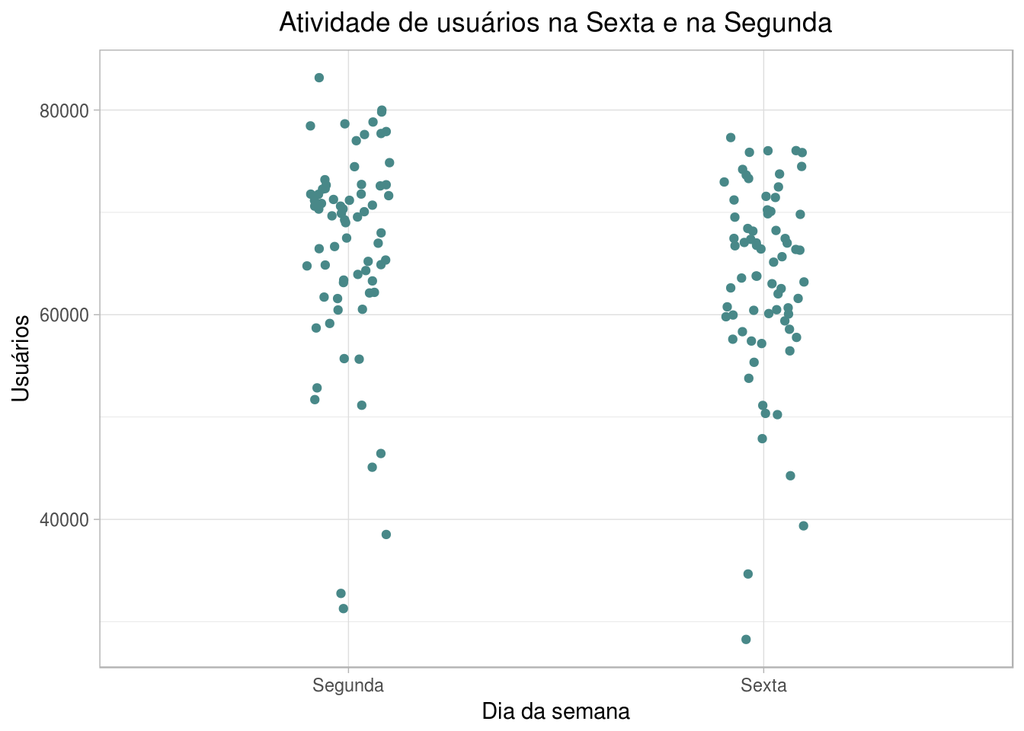

```r
set.seed(123)
dados.github.segsex %>%
  ggplot(aes(x = isSEX, y = total)) +
  geom_jitter(width = .1, color = "#488888") +
  labs(title = "Atividade de usuários na Sexta e na Segunda", x = "Dia da semana", y = "Usuários") +
  scale_x_discrete(labels= c("Segunda", "Sexta")) +
  theme(plot.title = element_text(hjust = 0.5))
```

Novamente não parece haver uma diferença muito clara. Vamos olhar o intervalo de confiança da diferença das medianas para as duas observações e identificar se essa diferença é significativa ou não.

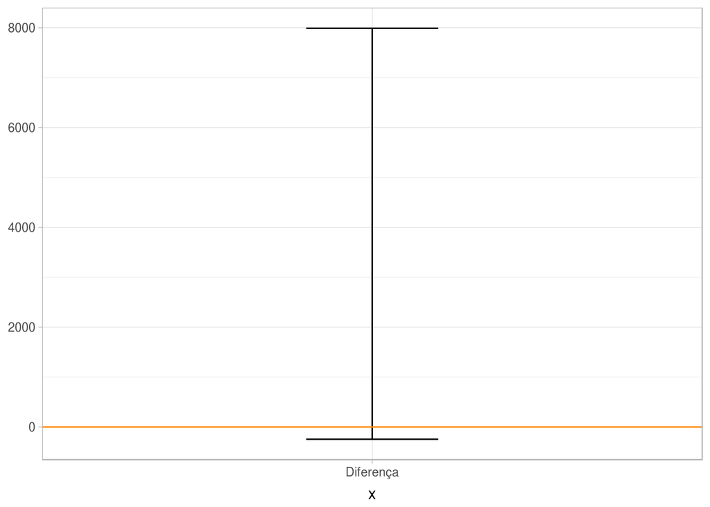

```r
median.dados.segsex <- bootstrap2(dados.github.segsex$total,
                          treatment = dados.github.segsex$isSEX,
                          median,
                          R = 30000)

median.dados.segsex.ci <- CI.percentile(median.dados.segsex, probs = c(.025, .975))

data.frame(median.dados.segsex.ci) %>%
  ggplot() +
  geom_errorbar(aes(x = "Diferença", ymin = X2.5., ymax = X97.5.), width = .2) +
  geom_hline(yintercept = 0, colour = "darkorange")
```

Com 95% de confiança o intervalo da diferença mediana entre os dois grupos está no intervalo -246, 7989. Dessa vez percebemos que o intervalo contém o zero, o que pode indicar que existe a possibilidade de que a diferença verdadeira seja nenhuma ou seja 0, mas pode ser que seja algo bem maior como 8000 usuários. Portanto, não podemos concluir se existe uma diferença significativa de popularidade entre segunda e sexta, pode ser que seja de 8000 (atividade na segunda - atividade na sexta) mas pode ser nula também ou até negativa, ou seja na sexta há mais atividade.

## Pergunta 2

**Qual a proporção de atividade de usuários no Github no final de semana com relação toda a semana?**

Para responder essa pergunta estamos interessados em observar por semana, em 2016, a proporção de atividade de usuários no fim da respectiva semana com relação a semana inteira. Para afirmar com 95% de confiança utilizaremos o bootstrap e o intervalo de confiança.

```r
dados.github.week <- dados.github %>%
  filter(the_year == 2016) %>%
  unite("date", the_year, the_month, month_day, sep = "-") %>%
  mutate(date = as.Date(strptime(date, "%Y-%m-%d"))) %>%
  group_by(date) %>%
  summarise(total = sum(users)) %>%
  mutate(week = week(date)) %>%
  mutate(isFDS = is.weekend(date))
```

```r
dados.week.summ <- dados.github.week %>%
  group_by(week, isFDS) %>%
  summarise(n = sum(total)) %>%
  spread(isFDS, n) %>%
  rename("fds" = `TRUE`) %>%
  rename("mds" = `FALSE`)
```

```r
dados.week.summ <- dados.week.summ %>%
  mutate(prop_fds = fds / (fds + mds))
```

```r
median.prop.fds = bootstrap(dados.week.summ,
                        median(prop_fds),
                        R = 30000) %>%
    CI.percentile(probs = c(.025, .975))
```

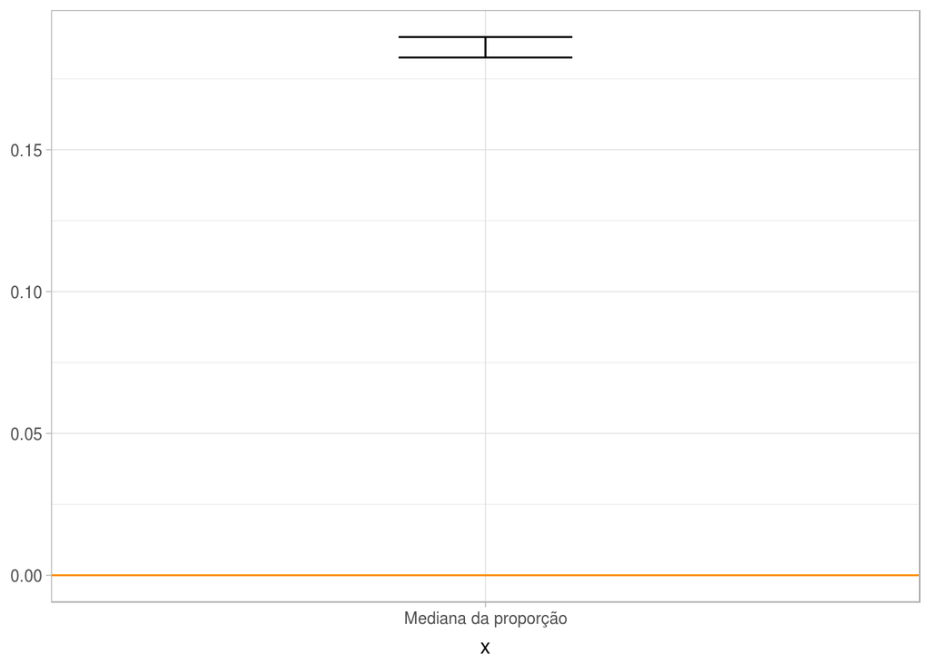

```r
data.frame(median.prop.fds) %>%
  ggplot() +
  geom_errorbar(aes(x = "Mediana da proporção", ymin = X2.5., ymax = X97.5.), width = .2) +
  geom_hline(yintercept = 0, colour = "darkorange")
```

A mediana da proporção da população, com 95% de confiança está no intervalo entre 0.1825204, 0.1897423. Ou seja, se levarmos em consideração de que se cada dia da semana tivesse a mesma proporção de usuários com relação a semana toda teríamos 0.1428571 % por dia, ou ainda 0.2857143 % em um final de semana, mas como observamos o intervalo mostrado com 95% de confiança diz que no final de semana a proporção está entre 0.1825204, 0.1897423. Ou seja, considerando cada semana do ano de 2016, é possível afirmar que no final de semana houve menor atividade de usuários no Github do que no meio de semana.

### Pergunta derivada

**Qual a diferença entre as proporções de atividades de usuários no meio de semana para o fim de semana?**

Para responder essa pergunta precisamos ter as informações para cada semana de 2016 das proporções de atividade no fim de semana e no meio de semana. Claro que o fim de semana é considerado menor e só possui 2 dias, mas ainda sim essa diferença pode ajudar a entender como a atividade dos usuários no Github muda entre dias úteis e não.

```r
dados.week.summ <- dados.week.summ %>%
  mutate(prop_mds = mds / (fds + mds))
```

```r
dados.week.diff <- dados.week.summ %>%
  mutate(prop_diff = prop_mds - prop_fds) %>%
  select(week, prop_diff)
```

```r
median.diff = bootstrap(data = dados.week.diff$prop_diff, median, R = 30000)

median.diff.paired = CI.percentile(median.diff, probs = c(.025, .975))
```

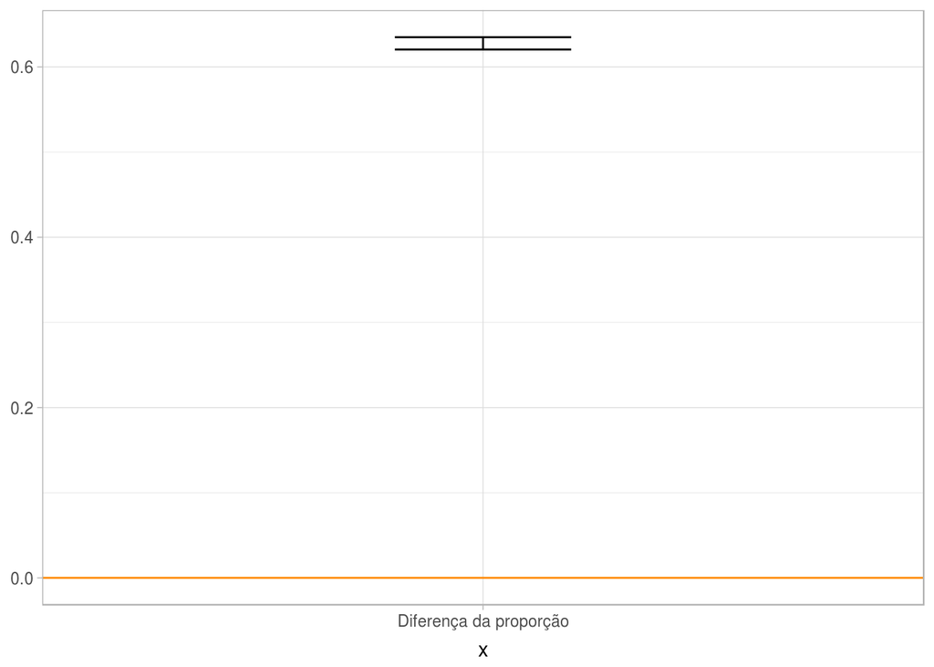

```r
data.frame(median.diff.paired) %>%
  ggplot() +
  geom_errorbar(aes(x = "Diferença da proporção", ymin = X2.5., ymax = X97.5.), width = .2) +
  geom_hline(yintercept = 0, colour = "darkorange")
```

Com 95% de confiança a diferença entre as proporções do meio de semana e o fim de semana está no intervalo entre 0.6205155, 0.6349592. Ou seja, é possível afirmar que existe mais de 60 % de atividade durante a semana do que no fim de semana para cada semana do ano de 2016. Com essa resposta, a da questão anterior e a resposta contida no checkpoint anterior (Para java e go) é possível ter certa confiança em afirmar que existe sim uam diminuição da atividade durante o fim de semana. Afinal quem não precisa descansar um pouco né? Eu mesmo irei descansar agora que já tá bem tarde aqui, talvez você queira fazer o mesmo. Obrigado pela leitura e atenção até aqui. Até a próxima análise!!!